# Q4 Reproducible Data Assignment

Candidate number: 1052140

04/12/2022

# Reproducible data

This document demonstrates reproducible analysis using the Palmer Penguins data set.

```r
# Load the data
penguins_raw <- read.csv('data_raw/penguins_raw.csv')
```

```r
# Clean the data
source('functions/cleaning.r')
penguins_clean <- cleaning(penguins_raw)
```

## Statistical Test

Using analysis of covariance (ANCOVA) to assess whether the explanatory variables sex and flipper length effect the body mass of Gentoo penguins, and whether there is an interaction between these two variables.

```r
# Filter data to just include Gentoo Penguins
penguins_gentoo <- filter(penguins_clean, species == 'Gentoo penguin (Pygoscelis papua)')
```

```r
# Remove the missing values from the Gentoo data set in the relevant columns
source('functions/cleaning.r')
penguins_gentoo_clean <- remove_empty_mass_flipper_sex(penguins_gentoo)
```

### Hypotheses

**Null hypothesis:** the effect of sex on body mass does not depend on flipper length (and vice versa)  
**Alternative hypothesis:** the effect of sex on body mass does depend on flipper length (and vice versa)

```r
# Fit a linear model with an interactive term
gentoo_mod1 <- lm(body_mass_g ~ sex*flipper_length_mm, penguins_gentoo_clean)
```

```r
# Output of the statistical test
summary(gentoo_mod1)
```

```
##
## Call:
## lm(formula = body_mass_g ~ sex * flipper_length_mm, data = penguins_gentoo_clean)
##
## Residuals:
##     Min      1Q  Median      3Q     Max
## -633.76 -182.04   -2.65  179.75  825.03
##
## Coefficients:
##                            Estimate Std. Error t value Pr(>|t|)
## (Intercept)               -2812.895   1986.822  -1.416 0.159544
## sexMALE                    4256.677   2422.476   1.757 0.081552 .
## flipper_length_mm            35.225      9.339   3.772 0.000258 ***
## sexMALE:flipper_length_mm   -16.985     11.240  -1.511 0.133504
## ---
## Signif. codes:  0 '***' 0.001 '**' 0.01 '*' 0.05 '.' 0.1 ' ' 1
##
## Residual standard error: 274.8 on 115 degrees of freedom
## Multiple R-squared:  0.7073, Adjusted R-squared:  0.6996
## F-statistic: 92.62 on 3 and 115 DF,  p-value: < 2.2e-16
```

Interpretation of results:  
- The P value of the interactive term (p = 0.133504) is not significant. Therefore it is most appropriate to refit the model without the interaction.

### Hypotheses

(For main effects of explanatory variables without an interactive term)

**Null hypothesis (sex):** The mean body mass of each sex is not significantly different  
**Alternative hypothesis (sex):** The mean body mass of each sex is significantly different

**Null hypothesis (flipper length):** The slope of flipper length against body mass is not significantly different from zero  
**Alternative hypothesis (flipper length):** The slope of flipper length against body mass is significantly different from zero

```r
#Fit a linear model without an interactive term
gentoo_mod2 <- lm(body_mass_g ~ sex+flipper_length_mm, penguins_gentoo_clean)
```

```r
# Output of the statistical test
summary(gentoo_mod2)
```

```
##
## Call:
## lm(formula = body_mass_g ~ sex + flipper_length_mm, data = penguins_gentoo_clean)
##
## Residuals:
##     Min      1Q  Median      3Q     Max
## -619.13 -182.37    5.87  171.12  827.88
##
## Coefficients:
##                   Estimate Std. Error t value Pr(>|t|)
## (Intercept)       -318.691   1112.019  -0.287    0.775
## sexMALE            597.501     68.552   8.716 2.38e-14 ***
## flipper_length_mm   23.499      5.225   4.497 1.64e-05 ***
## ---
## Signif. codes:  0 '***' 0.001 '**' 0.01 '*' 0.05 '.' 0.1 ' ' 1
##
## Residual standard error: 276.3 on 116 degrees of freedom
## Multiple R-squared:  0.7015, Adjusted R-squared:  0.6963
## F-statistic: 136.3 on 2 and 116 DF,  p-value: < 2.2e-16
```

Interpretation of results:  
- Second row, P<0.05, shows that the difference between body mass for males and females is significantly different from zero. Indicates that sex has a significant effect on body mass. Males are heavier than females.  
- Third row, P<0.05, shows that the gradient of the line is significantly different from zero. Indicates that flipper length has a significant effect on body mass. Penguins with longer flippers weigh more.

## Figure

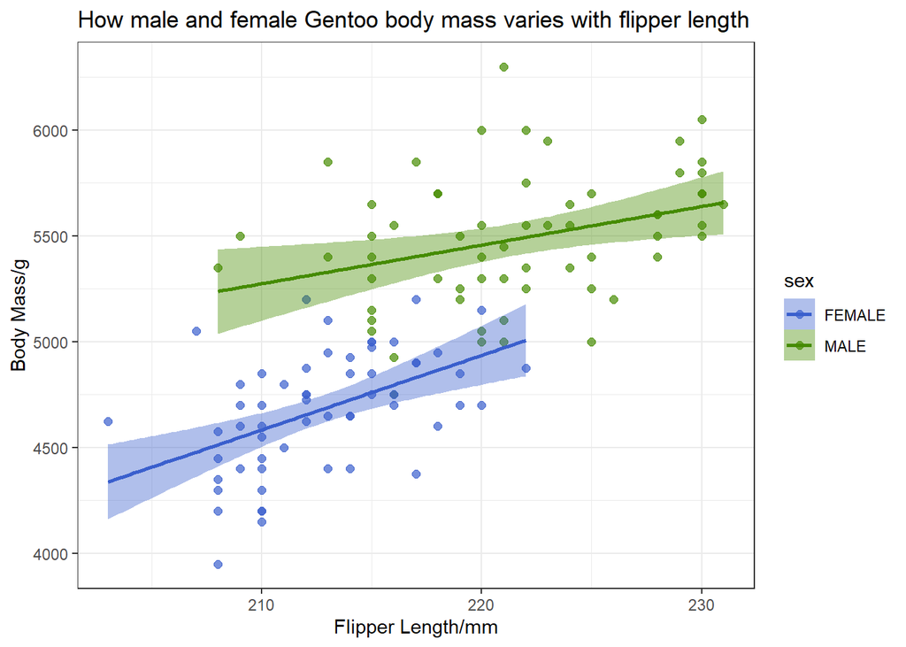

```r
# Communication of statistical test via a figure
# ANCOVA test, using a linear model without an interaction term
source('functions/plotting.r')
gentoo_ancova_plot <- ancova_plot(penguins_gentoo_clean)
gentoo_ancova_plot
```

```r
# Save the figure
source('functions/plotting.r')
save_gentoo_svg(penguins_gentoo_clean,
                'figures/gentoo_ancova.svg',
                size = 15, scaling = 0.85)
```